# **Part A: Convolutional Neural Network**

## __Previously__

1. 31 x 31 Baseline Model was done
2. Vgg_Model, CNN model 1 and CNN model 2 was decided as the best 3 models

## __Import Libraries__

Here is to import all the necessary libraries

```python
# !unzip 1.zip
```

```python
%pip install tensorflow_addons keras-tuner pandas matplotlib seaborn scikit-learn tqdm efficientnet numba
```

```python
# !sudo nvidia-smi --gpu-reset -i 0
```

### Other Imports

```python
import numpy as np
import pandas as pd

import seaborn as sns

from matplotlib import pyplot as plt

from sklearn.metrics import classification_report, roc_auc_score, average_precision_score, confusion_matrix, cohen_kappa_score, matthews_corrcoef
from sklearn.metrics import classification_report,accuracy_score, confusion_matrix
from sklearn.decomposition import PCA
from sklearn.preprocessing import Normalizer
from sklearn.metrics import classification_report, accuracy_score

import os, time, math, datetime, warnings, pytz, glob
from IPython.display import display
from functools import reduce
import absl.logging
from tqdm import tqdm
import logging
from efficientnet.tfkeras import EfficientNetB3

absl.logging.set_verbosity(absl.logging.ERROR)
logging.getLogger('tensorflow').disabled = True
warnings.filterwarnings('ignore')
```

### Tensorflow Import

```python
import tensorflow as tf
from tensorflow.keras.utils import Sequence, to_categorical
from tensorflow import expand_dims
from tensorflow.keras import Sequential
from tensorflow.keras import layers as L
from tensorflow.keras import backend as K
from tensorflow.image import random_flip_left_right, random_crop, resize_with_crop_or_pad
from tensorflow.keras.utils import to_categorical, plot_model
from tensorflow.keras.models import Model, load_model
from tensorflow.keras.layers import (Dense, Input, InputLayer, Normalization, Flatten,BatchNormalization,
    Dropout,Conv2D, GlobalAveragePooling2D, MaxPooling2D, ReLU, Layer,Activation, Multiply, AveragePooling2D,
    Add, RandomRotation,Resizing, Rescaling, Reshape, Concatenate, concatenate, Lambda,LeakyReLU, ZeroPadding2D)
from tensorflow.keras.callbacks import EarlyStopping, ModelCheckpoint, LearningRateScheduler, ReduceLROnPlateau, TerminateOnNaN, TensorBoard, CSVLogger, Callback
from tensorflow.keras.backend import clear_session
from tensorflow.keras.optimizers import RMSprop, SGD, Adam, Adagrad, Adamax
from tensorflow.keras.regularizers import l2, L2
from tensorflow.keras.optimizers.schedules import *
from tensorflow.keras.metrics import FalseNegatives, categorical_crossentropy, sparse_categorical_crossentropy
from tensorflow.keras.losses import CategoricalCrossentropy
from tensorflow.keras.preprocessing.image import ImageDataGenerator
from tensorflow.image import *
from tensorflow_addons.optimizers import SWA
from tensorflow.keras import layers

from kerastuner.tuners import Hyperband
from kerastuner import RandomSearch
from kerastuner import HyperModel
# Setting a seaborn style
sns.set(style="whitegrid")
```

### Set the seed of this notebook

```python
seed = 32
tf.random.set_seed(seed)
np.random.seed(seed)
```

## __Check for GPU__

Here is check the available GPUs and set the memory growth

```python
gpus = tf.config.experimental.list_physical_devices('GPU')
if gpus:
    try:
        for gpu in gpus:
            tf.config.experimental.set_memory_growth(gpu, True)

        logical_gpus = tf.config.experimental.list_logical_devices('GPU')
        print(f"{len(gpus)} Physical GPUs, {len(logical_gpus)} Logical GPU")
    except RuntimeError as e:
        print(e)
```

```
1 Physical GPUs, 1 Logical GPU
```

```python
!nvidia-smi
```

```
Sun Nov 26 07:13:06 2023
+---------------------------------------------------------------------------------------+
| NVIDIA-SMI 535.113.01             Driver Version: 535.113.01   CUDA Version: 12.2     |
|-----------------------------------------+----------------------+----------------------+
| GPU  Name                 Persistence-M | Bus-Id        Disp.A | Volatile Uncorr. ECC |
| Fan  Temp   Perf          Pwr:Usage/Cap |         Memory-Usage | GPU-Util  Compute M. |
|                                         |                      |               MIG M. |
|=========================================+======================+======================|
|   0  NVIDIA GeForce RTX 4090        On  | 00000000:01:00.0 Off |                  Off |
| 62%   42C    P2              63W / 450W |    548MiB / 24564MiB |      5%      Default |
|                                         |                      |                  N/A |
+-----------------------------------------+----------------------+----------------------+

+---------------------------------------------------------------------------------------+
| Processes:                                                                            |
|  GPU   GI   CI        PID   Type   Process name                            GPU Memory |
|        ID   ID                                                             Usage      |
|=======================================================================================|
+---------------------------------------------------------------------------------------+
```

## __Import dataset__

Here is to import the dataset and proceed to do analysis on it

### 31 x 31 Images

```python
data_small = tf.keras.utils.image_dataset_from_directory('Dataset for CA1 part A/train'  ,
                                                   color_mode='rgb',
                                                   image_size=(31,31))
data_small
```

```
Found 9028 files belonging to 15 classes.
```

```
<BatchDataset element_spec=(TensorSpec(shape=(None, 31, 31, 3), dtype=tf.float32, name=None), TensorSpec(shape=(None,), dtype=tf.int32, name=None))>
```

#### Train Data

```python
X_train_small = []
y_train_small = []

for images, labels in tqdm(data_small):
    images = tf.image.rgb_to_grayscale(images)
    X_train_small.append(images)
    y_train_small.append(labels)

X_train_small = np.concatenate(X_train_small, axis=0)
X_train_small = np.squeeze(X_train_small, axis=-1)
y_train_small = np.concatenate(y_train_small, axis=0)
```

#### Validation Data

```python
val_data_small = tf.keras.utils.image_dataset_from_directory('Dataset for CA1 part A/validation'  ,
                                                   color_mode='rgb',
                                                   image_size=(31,31))
val_data_small
```

```
Found 3000 files belonging to 15 classes.
```

```
<BatchDataset element_spec=(TensorSpec(shape=(None, 31, 31, 3), dtype=tf.float32, name=None), TensorSpec(shape=(None,), dtype=tf.int32, name=None))>
```

```python
X_val_small = []
y_val_small = []

for images, labels in tqdm(val_data_small):
    images = tf.image.rgb_to_grayscale(images)
    X_val_small.append(images)
    y_val_small.append(labels)

X_val_small = np.concatenate(X_val_small, axis=0)
X_val_small = np.squeeze(X_val_small, axis=-1)
y_val_small = np.concatenate(y_val_small, axis=0)
```

#### Test Data

```python
test_data_small = tf.keras.utils.image_dataset_from_directory('Dataset for CA1 part A/test'  ,
                                                   color_mode='rgb',
                                                   image_size=(31,31))
test_data_small
```

```
Found 3000 files belonging to 15 classes.
```

```
<BatchDataset element_spec=(TensorSpec(shape=(None, 31, 31, 3), dtype=tf.float32, name=None), TensorSpec(shape=(None,), dtype=tf.int32, name=None))>
```

```python
X_test_small = []
y_test_small = []

for images, labels in tqdm(test_data_small):
    images = tf.image.rgb_to_grayscale(images)
    X_test_small.append(images)
    y_test_small.append(labels)

X_test_small = np.concatenate(X_test_small, axis=0)
X_test_small = np.squeeze(X_test_small, axis=-1)
y_test_small = np.concatenate(y_test_small, axis=0)
```

```python
labels_dict = os.listdir('Dataset for CA1 part A/train')
labels_dict = {idx: label for idx, label in enumerate(labels_dict)}
print(labels_dict)
```

```
{0: 'Bean', 1: 'Bitter_Gourd', 2: 'Bottle_Gourd', 3: 'Brinjal', 4: 'Broccoli', 5: 'Cabbage', 6: 'Capsicum', 7: 'Carrot', 8: 'Cauliflower', 9: 'Cucumber', 10: 'Papaya', 11: 'Potato', 12: 'Pumpkin', 13: 'Radish', 14: 'Tomato'}
```

## __Required Functions__

Here is to define all the required functions

```python
LR = 0.01
MOMENTUM = 0.9
WEIGHT_DECAY = 0.0005
val_split = 0.2
max_epochs = 100
```

```python
y_train_small = to_categorical(y_train_small)
y_val_small = to_categorical(y_val_small)
```

### VGG 16 Model

```python
def vgg_conv_layer(filters, kernel_size=3, activation='relu', weight_decay=WEIGHT_DECAY):
    return Sequential([
        Conv2D(filters, kernel_size, padding='same', activation=None, kernel_regularizer=l2(weight_decay)),
        BatchNormalization(),
        ReLU() if activation == 'relu' else activation
    ])

def vgg_conv_block(no_layers, filters, activation='relu'):
    block = Sequential()
    for _ in range(no_layers):
        block.add(vgg_conv_layer(filters, activation=activation))
    block.add(MaxPooling2D(pool_size=(2, 2), strides=2))
    return block

class VGGNet(Model):
    def __init__(self, input_shape, num_classes, name='VGGNet_Baseline'):
        super(VGGNet, self).__init__(name=name)
        self.vgg_blocks = [
            vgg_conv_block(2, 32, activation='relu'),
            vgg_conv_block(3, 64, activation='relu'),
            vgg_conv_block(3, 128, activation='relu'),
            vgg_conv_block(3, 256, activation='relu'),
        ]
        self.global_pool = GlobalAveragePooling2D()
        self.classifier = Sequential([
            Dropout(0.3),
            Dense(num_classes, activation='softmax')
        ])

    def call(self, inputs):
        x = inputs
        for block in self.vgg_blocks:
            x = block(x)
        x = self.global_pool(x)
        return self.classifier(x)

    def build(self, input_shape):
        inputs = Input(shape=(31,31,1))
        model = Model(inputs=inputs, outputs=self.call(inputs), name=self.name)
        return model
input_shape = (31, 31, 1)
num_classes = 15
vgg = VGGNet(input_shape, num_classes)
vgg_model = vgg.build(input_shape)
optimizer = tf.keras.optimizers.Adam(learning_rate=0.01)
vgg_model.compile(optimizer=optimizer, loss='categorical_crossentropy', metrics=['accuracy'])
```

### CNN Baseline 2

```python
def CNN2(name='CNN2_Baseline'):

    filters_list = [128, 128, 128]

    model = Sequential()

    # Add initial convolutional layers
    model.add(Conv2D(filters=filters_list[0], kernel_size=(3, 3), padding='same', input_shape=(31, 31, 1)))
    model.add(BatchNormalization())
    model.add(ReLU())

    model.add(Conv2D(filters=filters_list[1], kernel_size=(3, 3), padding='same'))
    model.add(BatchNormalization())
    model.add(ReLU())

    for filters in filters_list:
        model.add(Conv2D(filters=filters, kernel_size=(3, 3), padding='same'))
        model.add(BatchNormalization())
        model.add(ReLU())

    model.add(GlobalAveragePooling2D())
    model.add(Dense(256, activation='relu'))
    model.add(Dense(15, activation='softmax'))

    model.compile(optimizer='adam', loss='categorical_crossentropy', metrics=['accuracy'])
    model.summary()
    return model
```

```python
no = lambda x : x
def data_before_train(self, aug_func=no):
    train_ds = tf.data.Dataset.from_tensor_slices((X_train_small, y_train_small)).map(lambda x, y : (expand_dims(x, -1), y))
    val_ds = tf.data.Dataset.from_tensor_slices((X_val_small, y_val_small)).shuffle(128 * 100).batch(128).map(lambda x, y : (expand_dims(x, -1), y)).prefetch(tf.data.AUTOTUNE)
    train_ds = train_ds.map(lambda x, y : (aug_func(x), y), num_parallel_calls=tf.data.AUTOTUNE).shuffle(128 * 100).batch(128).prefetch(tf.data.AUTOTUNE)
    return train_ds, val_ds
train_ds, val_ds = data_before_train(no)
```

```python
def evaluation_test(model, X_val, y_val, LABELS):
    final_predictions = model.predict(X_val)
    final_predictions_final = np.argmax(final_predictions, axis=1)
    y_test_final = np.argmax(y_val, axis=1) if y_val.ndim == 2 else y_val
    classification_results = classification_report(y_test_final, final_predictions_final, target_names=LABELS.values(), output_dict=True)

    print('Accuracy:', accuracy_score(y_test_final, final_predictions_final))
    result = pd.DataFrame(classification_results).transpose().sort_values('f1-score')
    return result
```

```python
def plot_classification_heatmap(df):
    heatmap_data = df.drop(['accuracy', 'macro avg', 'weighted avg']).iloc[:, :-1]
    plt.figure(figsize=(10, 8))
    sns.heatmap(heatmap_data, annot=True, fmt=".2f", cmap="Blues")
    plt.title("Classification Report Heatmap")
    plt.show()
```

```python
class Evaluator:
  def __init__(self, path=None, project_name="CNN_CA1"):
      # Initialize wandb
      self.project_name = project_name

      # Your existing initialization code
      if path:
          self.result = pd.read_csv(path, sep=';')
      else:
          cols = ['Model Name', 'Batch Size', "Train Loss", "Test Loss", "Train Acc", "Test Acc", "Remarks"]
          self.result = pd.DataFrame(columns=cols)

      self.callback = [
          TerminateOnNaN()
      ]
      # self.api = wandb.Api()

  def train_model(self, model, train, val, hyperparameters, callbacks):
    tf.keras.backend.clear_session()
    epochs = hyperparameters['max_epochs']
    batch_size = 64

    if val is None:
      X_train, y_train = train
      return model.fit(X_train, y_train, epochs=epochs, batch_size=64, validation_split = hyperparameters["val_split"], callbacks=callbacks).history
    else:
      return model.fit(train, validation_data = val, epochs = epochs, batch_size = batch_size , callbacks=callbacks).history

  def model_evaluate(self, train, val, model, hyperparameters, callbacks=None, plot_loss=True, remarks=""):
      tf.keras.backend.clear_session()
      # wandb.init(project=self.project_name)
      callbacks = (callbacks or [EarlyStopping(monitor='val_accuracy', patience=10, restore_best_weights=True), ReduceLROnPlateau(patience=5)]) + self.callback
      history = self.train_model(model, train, val, hyperparameters, callbacks)
      bestval_index = np.argmax(history['val_accuracy'])


      if plot_loss:
          try:
              fig = plot_model_history(history)
          except Exception as e:
              print(e, 'here')
              print("error creating loss curve")
              fig = None

      result = {
          "Model Name": model.name,
          "Epochs": len(history["loss"]),
          "Batch Size": hyperparameters["batch_size"],
          "Train Loss": history["loss"][bestval_index],
          "Test Loss": history["val_loss"][bestval_index],
          "Train Acc": history["accuracy"][bestval_index],
          "Test Acc": history["val_accuracy"][bestval_index]
      }
      # wandb.log({
      #     "Model Name": model.name,
      #     "Epochs": len(history["loss"]),
      #     "Batch Size": hyperparameters["batch_size"],
      #     "Train Loss": history["loss"][bestval_index],
      #     "Test Loss": history["val_loss"][bestval_index],
      #     "Train Acc": history["accuracy"][bestval_index],
      #     "Test Acc": history["val_accuracy"][bestval_index],
      # })

      # wandb.finish()
      return result, fig

  def _train_model(self, model, training_data, validation_data, hyperparameters, callbacks):
      tf.keras.backend.clear_session()
      epochs = hyperparameters["max_epochs"]
      batch_size = hyperparameters["batch_size"]

      if validation_data is None:
          X_train, y_train = training_data
          return model.fit(X_train, y_train, epochs=epochs, batch_size=batch_size, validation_split=hyperparameters["val_split"], callbacks=callbacks).history

      return model.fit(training_data, validation_data=validation_data, epochs=epochs, batch_size=batch_size, callbacks=callbacks).history
```

```python
def plot_model_history(model_history):
    history_df = pd.DataFrame(model_history)
    fig, axs = plt.subplots(1, 2, figsize=(14, 5))

    axs[0].plot(history_df['loss'], 'g--', label='Training Loss')
    axs[0].plot(history_df['val_loss'], 'b-', label='Validation Loss')
    axs[0].set_title('Training and Validation Loss')
    axs[0].set_xlabel('Epochs')
    axs[0].set_ylabel('Loss')
    axs[0].legend()
    axs[0].grid(True)

    if 'accuracy' in history_df and 'val_accuracy' in history_df:
        axs[1].plot(history_df['accuracy'], 'g--', label='Training Accuracy')
        axs[1].plot(history_df['val_accuracy'], 'b-', label='Validation Accuracy')
        axs[1].set_title('Training and Validation Accuracy')
        axs[1].set_xlabel('Epochs')
        axs[1].set_ylabel('Accuracy')
        axs[1].legend()
        axs[1].grid(True)

    plt.tight_layout()
    plt.close(fig)

    def show():
        display(fig)

    return show
```

## __Feature Engineering - Data Augmentation__

- Model may not be as stable as we wnat hence
- **Is it possible to improve further with data augmentation ?**

```python
evaluator = Evaluator()
```

```python
columns = ["Model Name", "Epochs", "Batch Size", "Train Loss", "Test Loss", "Train Acc", "Test Acc",'Kappa', "Comments"]
overall = pd.DataFrame(columns=columns)
print(overall)
```

```
Empty DataFrame
Columns: [Model Name, Epochs, Batch Size, Train Loss, Test Loss, Train Acc, Test Acc, Kappa, Comments]
Index: []
```

### Setting up the baseParams

```python
base_hparams = {"val_split" : val_split, "max_epochs" : max_epochs,"batch_size" : 128}
steps_per_epoch = np.ceil(len(X_train_small) / 128)
steps_per_epoch
```

```
71.0
```

```python
def models_array():
    def baseline_model2(optimizer='adam', name='CNN_Baseline'):
        model = Sequential(name=name)

        # Input layer
        model.add(Input(shape=(31, 31, 1)))

        # First Convolutional Block
        model.add(Conv2D(64, (3, 3), padding='same', activation='relu'))
        model.add(BatchNormalization())
        model.add(MaxPooling2D(pool_size=(2, 2)))
        model.add(Dropout(0.3))

        # Second Convolutional Block
        model.add(Conv2D(128, (3, 3), padding='same', activation='relu'))
        model.add(BatchNormalization())
        model.add(MaxPooling2D(pool_size=(2, 2)))
        model.add(Dropout(0.3))

        model.add(Flatten())

        # Dense Block
        model.add(Dense(512, activation='relu'))
        model.add(BatchNormalization())
        model.add(Dropout(0.5))

        # Dense Block
        model.add(Dense(128, activation='relu'))
        model.add(BatchNormalization())
        model.add(Dropout(0.5))

        # Output Layer
        model.add(Dense(15, activation='softmax'))

        # Compile the model
        model.compile(optimizer=optimizer, loss='categorical_crossentropy', metrics=['accuracy'])

        model.summary()

        return model
    input_shape = (31, 31, 1)
    num_classes = 15

    vgg = VGGNet(input_shape, num_classes)
    vgg_model = vgg.build(input_shape)
    optimizer = tf.keras.optimizers.Adam(learning_rate=0.01)
    vgg_model.compile(optimizer=optimizer, loss='categorical_crossentropy', metrics=['accuracy'])

    cnn2 = CNN2()
    cnn = baseline_model2()
    models = [cnn, cnn2, vgg_model ]
    return models

model_names = ['CNN','CNN2','VGG_Baseline']
```

### Data Augmentation 1

- Provide flip to image horizontally and vertically randomly
- Randomly rotate the image of 90 degrees

```python
def data_augmentation_1(image):
    image = tf.image.random_flip_left_right(image)
    image = tf.image.random_flip_up_down(image)
    image = tf.image.rot90(image, k=tf.random.uniform(shape=[], minval=0, maxval=4, dtype=tf.int32))
    return image
```

#### Process the Train and Validation data

```python
def preprocess2(image, label):
    if len(image.shape) == 2:
        image = tf.expand_dims(image, axis=-1)
    image = data_augmentation_1(image)
    return image, label
```

```python
train_ds_basic = tf.data.Dataset.from_tensor_slices((X_train_small, y_train_small))
train_ds_basic = train_ds_basic.map(preprocess2).batch(128).prefetch(tf.data.AUTOTUNE)

val_ds_basic = tf.data.Dataset.from_tensor_slices((X_val_small, y_val_small))
val_ds_basic = val_ds_basic.map(preprocess2).batch(128).prefetch(tf.data.AUTOTUNE)
```

#### Visualise the images

```python
def visualisation(dataset, num_images, type, type2):
    plt.figure(figsize=(num_images * 3, 3))
    plt.suptitle(f'Image Visualization {type} on {type2} dataset')
    for images, labels in dataset.take(1):
        for i in range(num_images):
            ax = plt.subplot(1, num_images, i + 1)
            plt.imshow(images[i].numpy().squeeze(), cmap='gray')
            plt.axis("off")
    plt.show()
```

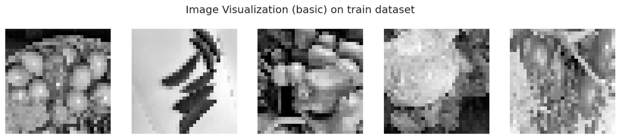

```python
visualisation(train_ds_basic,5,'(basic)','train')
```

#### Run the model

```python
figures = []
models = models_array()
for i in range(len(models)):
    print(f'Running {model_names[i]}')
    results, fig = evaluator.model_evaluate( train_ds_basic, val_ds_basic , models[i], base_hparams)
    results['Model Name'] = f'{model_names[i]} basic one'
    y_pred = models[i].predict(X_test_small)
    y_pred_classes = np.argmax(y_pred, axis=1)
    kappa = cohen_kappa_score(y_test_small, y_pred_classes)
    print("Cohen’s Kappa Score:", kappa)
    results['Kappa'] = kappa
    overall = pd.concat([overall, pd.DataFrame([results])], ignore_index=True)
    figures.append(fig)
```

```
Model: "sequential_32"
_________________________________________________________________
 Layer (type)                Output Shape              Param #
=================================================================
 conv2d_22 (Conv2D)          (None, 31, 31, 128)       1280

 batch_normalization_22 (Bat  (None, 31, 31, 128)      512
 chNormalization)

 re_lu_22 (ReLU)             (None, 31, 31, 128)       0

 conv2d_23 (Conv2D)          (None, 31, 31, 128)       147584

 batch_normalization_23 (Bat  (None, 31, 31, 128)      512
 chNormalization)

 re_lu_23 (ReLU)             (None, 31, 31, 128)       0

 conv2d_24 (Conv2D)          (None, 31, 31, 128)       147584

 batch_normalization_24 (Bat  (None, 31, 31, 128)      512
 chNormalization)

 re_lu_24 (ReLU)             (None, 31, 31, 128)       0

 conv2d_25 (Conv2D)          (None, 31, 31, 128)       147584

 batch_normalization_25 (Bat  (None, 31, 31, 128)      512
 chNormalization)

 re_lu_25 (ReLU)             (None, 31, 31, 128)       0

 conv2d_26 (Conv2D)          (None, 31, 31, 128)       147584

 batch_normalization_26 (Bat  (None, 31, 31, 128)      512
 chNormalization)

 re_lu_26 (ReLU)             (None, 31, 31, 128)       0

 global_average_pooling2d_2   (None, 128)              0
```

[output cut: 49 more lines]

```
 dropout_5 (Dropout)         (None, 128)               0

 dense_6 (Dense)             (None, 15)                1935

=================================================================
Total params: 3,357,199
Trainable params: 3,355,535
Non-trainable params: 1,664
_________________________________________________________________
Running CNN
Cohen’s Kappa Score: 0.7582142857142857
Running CNN2
Cohen’s Kappa Score: 0.9357142857142857
Running VGG_Baseline
Cohen’s Kappa Score: 0.7689285714285714
```